# Red Wine Dataset Exploration by Raj Dayal Natarajan

# Loading and understanding the data structure:

There are 13 variables (Including a serial id of the obervations) and 1599 observations for the dataset. One thing which pops out, is that there are no categorical variables. The variables are either discrete or continuous. The quality of the wine is the only variable which can be treated like a categorical or a discrete variable. I have created a new variable called as quality_factor which will be of type ‘factor’

In the dataset density is g/cm^3. I am converting it to g/dm^3 to maintain consistency with the other measures

Some of the variables might be correlated to each other - The different acidicty metrics. This needs to be checked - This will be done in bivariate section.

# Univariate Plots Section:

As a starting point, I am going to start with a summary table of quality of wines and a histogram for the same.The mean and median are quite close and the distribution of the quality of wines looks like a normal distribution. From the summary stats, the median is 6 and the mean is 5.63. More interestingly, we can observe that the bulk of the wines (95% of the wines) have been categorized as 5,6 or 7.

I am also using the reshape function ‘melt’ to plot all the histograms for all variables except ‘Serial’

```
##    Min. 1st Qu.  Median    Mean 3rd Qu.    Max.
##   3.000   5.000   6.000   5.636   6.000   8.000
```

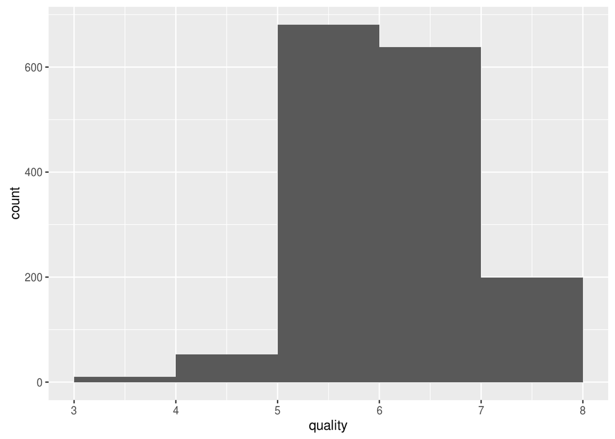

```
##
##   3   4   5   6   7   8
##  10  53 681 638 199  18
```

```
##    Min. 1st Qu.  Median    Mean 3rd Qu.    Max.
##   3.000   5.000   6.000   5.636   6.000   8.000
```

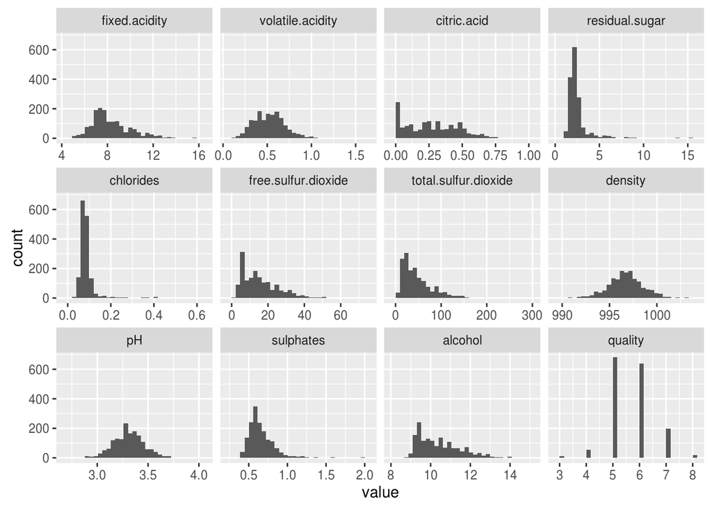

# Univariate Analysis:

Based on the histograms above, we can clearly see that many variables have a long tail.

I have transformed the corresponding histograms into a log scale below.

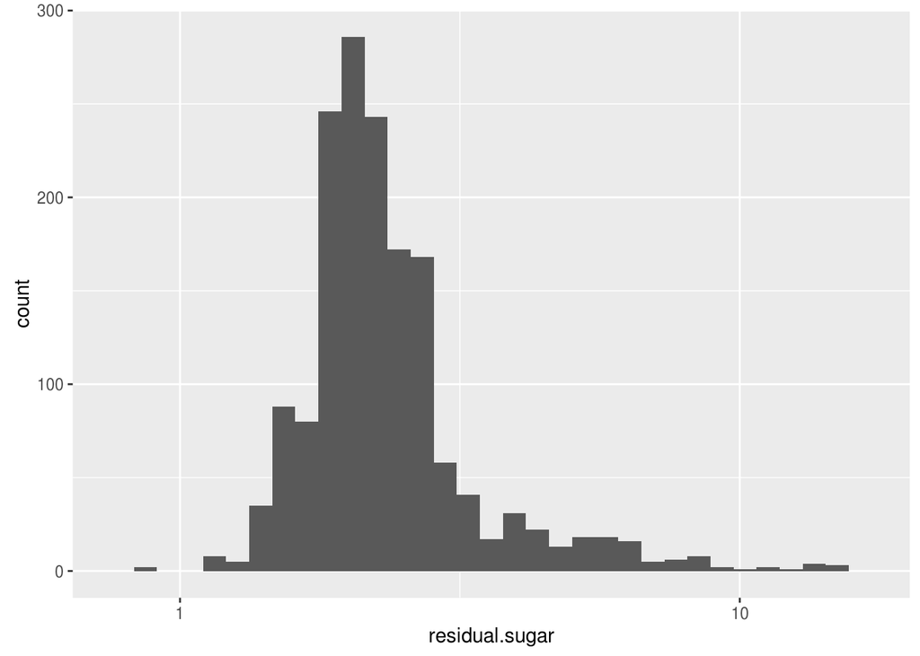

```
##    Min. 1st Qu.  Median    Mean 3rd Qu.    Max.
##   0.900   1.900   2.200   2.539   2.600  15.500
```

As can be seen, after the transformation, the residual sugar content appears normal. the median sugar in the normal scale is at 2.2 and the third quartile is at 2.6 g/dm^3. However, we do see outliers extending all the way to 15.5 as seen from the outliers to the right in the chart.

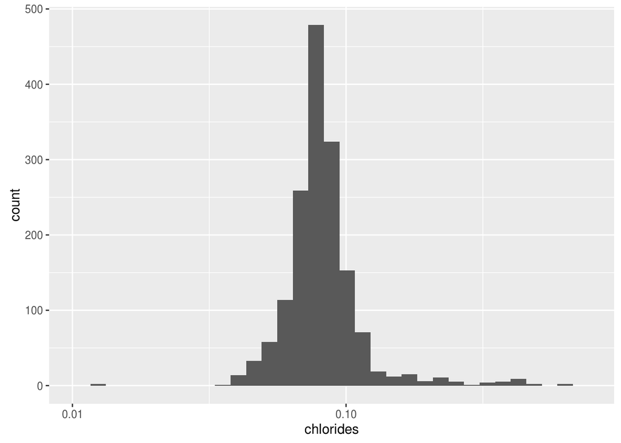

```
##    Min. 1st Qu.  Median    Mean 3rd Qu.    Max.
## 0.01200 0.07000 0.07900 0.08747 0.09000 0.61100
```

Chlorides also looks normally distributed with a median value of 0.079 g/dm^3. We do see a few outliers as seen from the right tail of the chart. In the normal scale they extend upto 0.61 g/dm^3

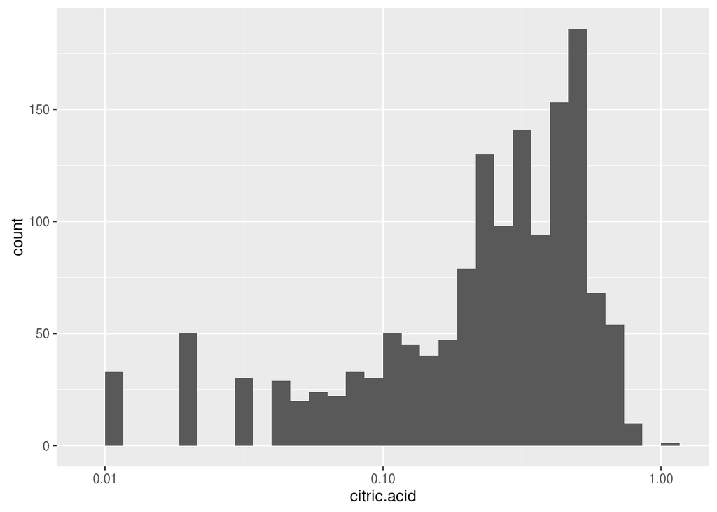

```
##    Min. 1st Qu.  Median    Mean 3rd Qu.    Max.
##   0.000   0.090   0.260   0.271   0.420   1.000
```

Citric acid content is normally distributed with a longer left tail as opposed to a right tail. the median of the distribution is at 0.26. The 25% percetile is at 0.09 g/dm^3. Some wines seem to have very low citric acid content in them. (typically associated with the freshness)

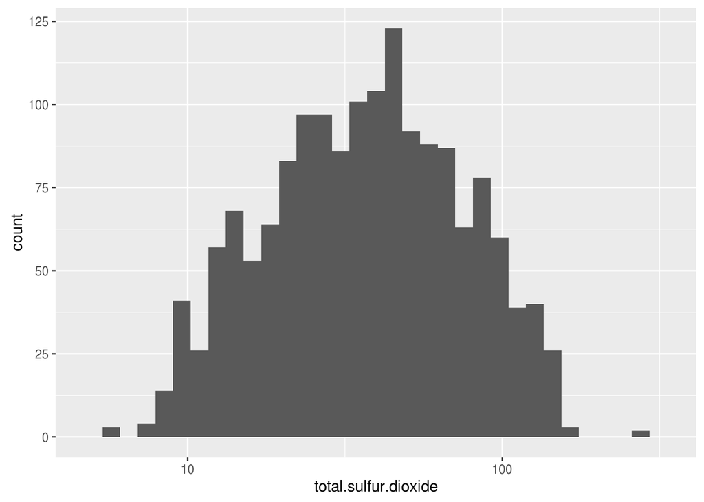

```
##    Min. 1st Qu.  Median    Mean 3rd Qu.    Max.
##    6.00   22.00   38.00   46.47   62.00  289.00
```

The total sulphur di-oxide is normal distribution visually, centered around a median of 38. there are two outliers however, one to the right and one to the left. They are wines having total sulphur di-oxie content of 289 and 6 mg/dm^3 respectively.

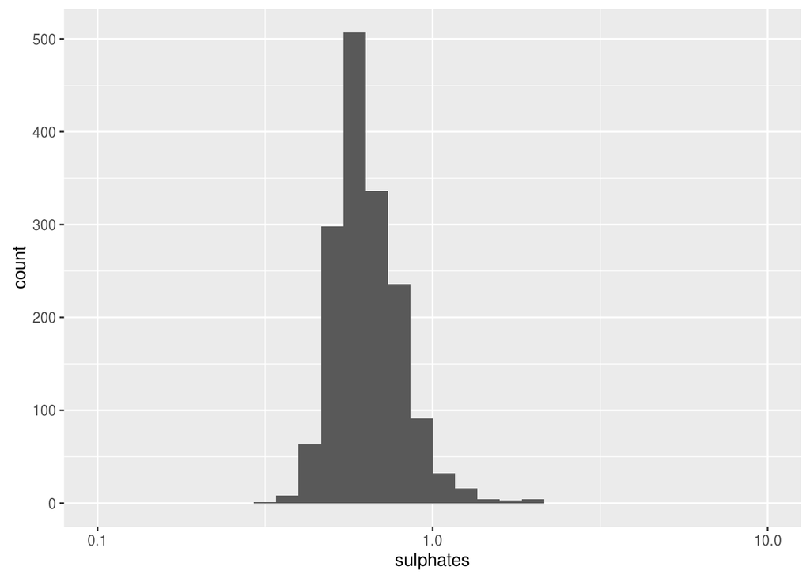

```
##    Min. 1st Qu.  Median    Mean 3rd Qu.    Max.
##  0.3300  0.5500  0.6200  0.6581  0.7300  2.0000
```

The sulphates across wines is also normally distributed following a clear bell shape.It has a slightly skewed on the right side, with a thin tail.

This can be inferred by lookng at the min, mean and max of the distribution respectively at 0.33, 0.65 and 2.

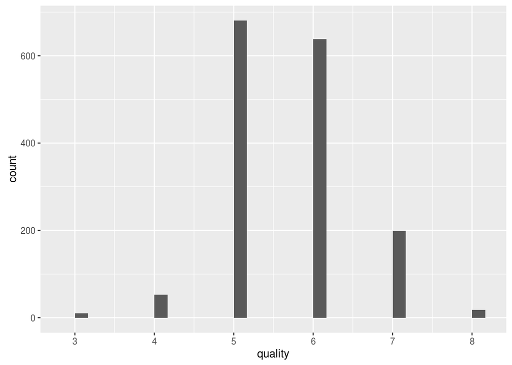

```
## <ScaleContinuousPosition>
##  Range:
##  Limits:    0 --    1
```

```
##    Min. 1st Qu.  Median    Mean 3rd Qu.    Max.
##   3.000   5.000   6.000   5.636   6.000   8.000
```

[output not shown]